# R base

## About R

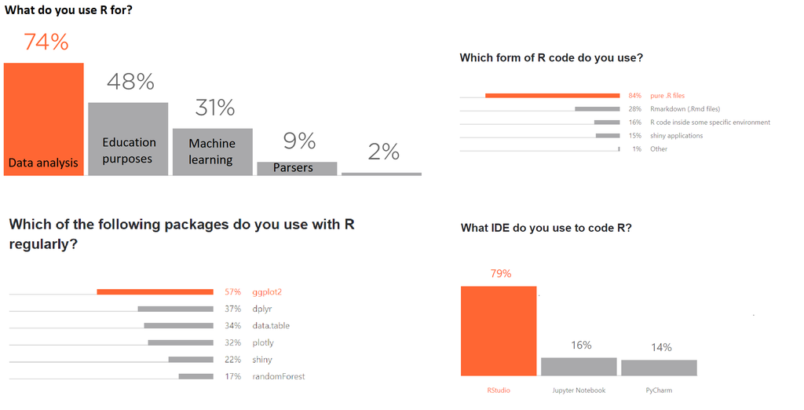

**Основные типы данных:**

- *logical* (TRUE/FALSE)
- *integer* ( целые числа)
- *numeric/double* (числа с плавающей точкой)
- *complex* (комплексные числа)
- *character* (строки)
- *raw* (байтовые последовательности)

## Базовые структуры данных

- вектор
- матрица
- список
- data.frame

## Вектор

индексированная последовательность элементов одного типа

```r
a <- c(2,3,4)
typeof(a)
```

```
## [1] "double"
```

```r
b <- as.character(a)
is.character(b)
```

```
## [1] TRUE
```

## Вектор (продолжение)

```r
a <- vector(length = 3)
typeof(a)
```

```
## [1] "logical"
```

```r
a[1] <- 2
a[2] <- 3
a[3] <- 4
typeof(a)
```

```
## [1] "double"
```

## Вектор (продолжение)

*Естественное приведение типов*: *logical* – *integer* – *double* - *character*

```r
v = c('one', 'two', 3, TRUE)
typeof(v)
```

```
## [1] "character"
```

## Последовательности

```r
2:10
```

```
## [1]  2  3  4  5  6  7  8  9 10
```

```r
seq(2, 10, by = 1.5)
```

```
## [1] 2.0 3.5 5.0 6.5 8.0 9.5
```

```r
seq(2, 10, length = 3)
```

```
## [1]  2  6 10
```

## Последовательности (продолжение)

```r
rep(1:3, times = 3)
```

```
## [1] 1 2 3 1 2 3 1 2 3
```

```r
rep(1:3, each = 4)
```

```
##  [1] 1 1 1 1 2 2 2 2 3 3 3 3
```

```r
rep(1:3, length.out = 5)
```

```
## [1] 1 2 3 1 2
```

## Именованный вектор

```r
a <- c(uno = 1, dos = 2, 'new' = 3, 4)
names(a)
```

```
## [1] "uno" "dos" "new" ""
```

```r
names(a) <- NA
```

## Векторизованные операции

(большинство базовых операций применяется поэлементно)

```r
a <- 1:4
a ^ 2
```

```
## [1]  1  4  9 16
```

```r
b <- 2:5
a * b
```

```
## [1]  2  6 12 20
```

```r
c(a,a) + b
```

```
## [1] 3 5 7 9 3 5 7 9
```

## Индексирование векторов

```r
x <- seq(10, 100, by = 10)
```

```r
x[3:5]
```

```
## [1] 30 40 50
```

```r
x[-3:-5]
```

```
## [1]  10  20  60  70  80  90 100
```

## Логические индексы

```r
x[rep(c(TRUE, FALSE), 5)]
```

```
## [1] 10 30 50 70 90
```

```r
x[x  > 77 & x < 99]
```

```
## [1] 80 90
```

## Мартрицы

```r
matrix(1:6, nrow = 2, ncol = 3, byrow = TRUE)
```

```
##      [,1] [,2] [,3]
## [1,]    1    2    3
## [2,]    4    5    6
```

```r
matrix(1:6, nrow = 2)
```

```
##      [,1] [,2] [,3]
## [1,]    1    3    5
## [2,]    2    4    6
```

## Атрибут dim

```r
m <- matrix(1:6, nrow = 2)
dim(m) <- NULL
m
```

```
## [1] 1 2 3 4 5 6
```

```r
dim(m) <- c(3, 2)
m
```

```
##      [,1] [,2]
## [1,]    1    4
## [2,]    2    5
## [3,]    3    6
```

_операторы (+, -, *, /) действуют поэлементно_

```r
m1 = matrix(1:10, nrow = 2)
m2 = matrix(2:11, nrow = 2)
m1 * m2
```

```
##      [,1] [,2] [,3] [,4] [,5]
## [1,]    2   12   30   56   90
## [2,]    6   20   42   72  110
```

*Полезные функции для матриц*

- rbind() / cbind() – функции присоединения матриц по строкам / столбцам
- rowSums() / colSums() – суммирование по строкам / столбцам
- rowMeans() / colMeans() - средние значения по строкам / столбцам

```r
m1 = matrix(1:10, nrow = 2)
m2 = matrix(2:11, nrow = 2)
rbind(m1, m2)
```

```
##      [,1] [,2] [,3] [,4] [,5]
## [1,]    1    3    5    7    9
## [2,]    2    4    6    8   10
## [3,]    2    4    6    8   10
## [4,]    3    5    7    9   11
```

```r
cbind(m1, m2)
```

```
##      [,1] [,2] [,3] [,4] [,5] [,6] [,7] [,8] [,9] [,10]
## [1,]    1    3    5    7    9    2    4    6    8    10
## [2,]    2    4    6    8   10    3    5    7    9    11
```

## apply()

```r
m = matrix(1:15, ncol = 3)
apply(m, MARGIN = 2, sum)
```

```
## [1] 15 40 65
```

```r
apply(m, MARGIN = 1:2, sum)
```

```
##      [,1] [,2] [,3]
## [1,]    1    6   11
## [2,]    2    7   12
## [3,]    3    8   13
## [4,]    4    9   14
## [5,]    5   10   15
```

## Именованные матрицы

```r
m <- matrix(1:10, ncol = 5)
rownames(m) <- c("row1", "row2")
colnames(m) <- paste0("column", 1:5)
m
```

```
##      column1 column2 column3 column4 column5
## row1       1       3       5       7       9
## row2       2       4       6       8      10
```

## Список

- *индексированная последовательность*

```r
list(1:2, 'data', matrix(1, nrow=2, ncol=2))
```

```
## [[1]]
## [1] 1 2
##
## [[2]]
## [1] "data"
##
## [[3]]
##      [,1] [,2]
## [1,]    1    1
## [2,]    1    1
```

```r
list(uno = 'uno', second = 2, 4:5, fourth = matrix(1, nrow = 2, ncol = 2))
```

```
## $uno
## [1] "uno"
##
## $second
## [1] 2
##
## [[3]]
## [1] 4 5
##
## $fourth
##      [,1] [,2]
## [1,]    1    1
## [2,]    1    1
```

## Конкатенация списков

```r
l1 = list(uno = 'uno', second = 2, 4:5, fourth = matrix(1, nrow = 2, ncol = 2))
l2 = list(first = 'first', 7:8 )
c(l1, l2)
```

```
## $uno
## [1] "uno"
##
## $second
## [1] 2
##
## [[3]]
## [1] 4 5
##
## $fourth
##      [,1] [,2]
## [1,]    1    1
## [2,]    1    1
##
## $first
## [1] "first"
##
## [[6]]
## [1] 7 8
```

## Доступ к элементам списка

```r
l1[1]
```

```
## $uno
## [1] "uno"
```

```r
l1[[1]]
```

```
## [1] "uno"
```

```r
l1$uno
```

```
## [1] "uno"
```

## Функция lappy()

```r
lapply(l1, length)
```

```
## $uno
## [1] 1
##
## $second
## [1] 1
##
## [[3]]
## [1] 2
##
## $fourth
## [1] 4
```

## DataFrame

- таблица из наблюдейний и переменных

```r
df = data.frame(x = 1:4, y = LETTERS[1:4], z = c(T, F))
head(df)
```

```
##   x y     z
## 1 1 A  TRUE
## 2 2 B FALSE
## 3 3 C  TRUE
## 4 4 D FALSE
```

```r
str(df)
```

```
## 'data.frame':    4 obs. of  3 variables:
##  $ x: int  1 2 3 4
##  $ y: chr  "A" "B" "C" "D"
##  $ z: logi  TRUE FALSE TRUE FALSE
```

## Атрибуты как у матриц

```r
nrow(df)
```

```
## [1] 4
```

```r
ncol(df)
```

```
## [1] 3
```

```r
dim(df)
```

```
## [1] 4 3
```

```r
colnames(df)
```

```
## [1] "x" "y" "z"
```

```r
rownames(df)
```

```
## [1] "1" "2" "3" "4"
```

## Атрибуты как у списков

```r
length(df)
```

```
## [1] 3
```

```r
names(df)
```

```
## [1] "x" "y" "z"
```

## Индексация, как у матриц

```r
df[3:4, -1]
```

```
##   y     z
## 3 C  TRUE
## 4 D FALSE
```

```r
df[c(T, F), c("z", "x")]
```

```
##      z x
## 1 TRUE 1
## 3 TRUE 3
```

## Индексация как у списков

```r
df$z
```

```
## [1]  TRUE FALSE  TRUE FALSE
```

```r
df[[3]]
```

```
## [1]  TRUE FALSE  TRUE FALSE
```

```r
df[["z"]]
```

```
## [1]  TRUE FALSE  TRUE FALSE
```

```r
df[df$x>2, 1:2]
```

```
##   x y
## 3 3 C
## 4 4 D
```

## cbind, rbind vs merge

```r
df1 = data.frame(id = id <- 1:3, letter1 = LETTERS[id])
df2 = data.frame(id = id+1, letter2 = LETTERS[2*id])
cbind(df1, df2, by = 'id')
```

```
##   id letter1 id letter2 by
## 1  1       A  2       B id
## 2  2       B  3       D id
## 3  3       C  4       F id
```

```r
merge(df1, df2, by = 'id')
```

```
##   id letter1 letter2
## 1  2       B       B
## 2  3       C       D
```

## Работа с директориями

#### getwd() - возвращает текущую директорию

```r
getwd()
```

```
## [1] "C:/Users/mary_/DataspellProjects/studyR"
```

#### setwd() - функция смены рабочей директории

```r
file.show('C:/Users/mary_/Documents/lectures/soy_phens.txt')
```

## Почему при импорте data.table числовые типы становытся строковыми?

- из-за пропущенных значений, отмеченных не как NA na.string(“NA”)
- из-за неверно указанного разделителя sep = “,”, dec = “.”
- из-за ковычек сопроводительного текста или комментариев quote, comment.char, skip

## Управляющие конструкции

```r
a <- 10
if (a > 10){
    print('a > 10')
} else {
    print("a <= 10")
}
```

```
## [1] "a <= 10"
```

```r
for (i in 1:5) print(i)
```

```
## [1] 1
## [1] 2
## [1] 3
## [1] 4
## [1] 5
```

## Создание функций

```r
add_two <- function(x){
    return(x + 2)
}

add_two(a)
```

```
## [1] 12
```

*Strings*

- для замены первой совпадающей подстроки в строке используется *sub(old, new, string)*
- для замены всех совпадающих подстрок в строке используется *gsub(old, new, string)*

```r
s <- "Curly is the smart one. Curly is funny, too."
sub("Curly", "Moe", s)
```

```
## [1] "Moe is the smart one. Curly is funny, too."
```

```r
gsub("Curly", "Moe", s)
```

```
## [1] "Moe is the smart one. Moe is funny, too."
```

*Enviroment*

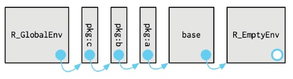

- создание объекта означает сохранение его в какой-то среде *enviroment*
- объекты созданные из консоли сохраняются в *global enviroment*( *рабочем пространстве*)
- если в какой-то среде запускается функция, то создается новая среда, дочерняя по отношению к к той среде, в которой эта функций создана
- среда, в которой в данный момент происходит выполнение программы называется *current enviroment*

*Enviroment*

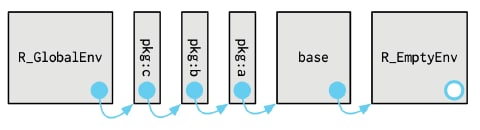

Доступные среды

```r
rlang::search_envs()
```

```
## [[1]] $ <env: global>
## [[2]] $ <env: package:stats>
## [[3]] $ <env: package:graphics>
## [[4]] $ <env: package:grDevices>
## [[5]] $ <env: package:utils>
## [[6]] $ <env: package:datasets>
## [[7]] $ <env: package:methods>
## [[8]] $ <env: Autoloads>
## [[9]] $ <env: package:base>
```

*Enviroment*

```r
#rlang::search_envs()
f <- function(f_x){
  g <- function(g_x){
    z <- 6
    print(environment())
    print(rlang::env_parent())
  }
  l <- 5
  g(5)
  print(environment())
  print(rlang::env_parent())
}
f()
```

```
## <environment: 0x0000000013ba6fa0>
## <environment: 0x0000000013ba6168>
## <environment: 0x0000000013ba6168>
## <environment: R_GlobalEnv>
```

*Enviroment*

*Оператор присваивания <<-*

- ‘<-’ всегда создает значение в текущей среде (current env)
- ‘<<-’ не создает значение в текущей среде, но создает значение в родительской среде (parent env)

```r
rm(list = ls())
l = 4
t <- function(x,y) x <- x/2
z = t(l)
ls.str()
```

```
## l :  num 4
## t : function (x, y)
## z :  num 2
```

```r
t <- function(x,y) x <<- x/2
z = t(l)
ls.str()
```

```
## l :  num 4
## t : function (x, y)
## x :  num 2
## z :  num 2
```

*Enviroment*

Cреда похожа на список и отличается от него тем, что

- имена уникальны
- имена не упорядочены
- каждая среда имеет родительскую среду (кроме empty enviroment)
- не копируются при изменении (modify in place)

*modify in place*

```r
e1 <- rlang::env(a = 1, b = 2, c = 3)
e2 <- e1
e1$c <- 4
ls.str(e1)
```

```
## a :  num 1
## b :  num 2
## c :  num 4
```

```r
ls.str(e2)
```

```
## a :  num 1
## b :  num 2
## c :  num 4
```

*copy-on-modify*

```r
e1 <- rlang::env(a = 1, b = 2, c = 3)
list_e1 <- as.list(e1)
list_e2 <- list_e1
list_e1$c <- 4
list_e1
```

```
## $a
## [1] 1
##
## $b
## [1] 2
##
## $c
## [1] 4
```

```r
list_e2
```

```
## $a
## [1] 1
##
## $b
## [1] 2
##
## $c
## [1] 3
```

*Аттрибуты*

- пары имя-значение, закрепленные за объектами (именованный список метаданных)
- *attributes()* - список атрибутов обекта
- *attr()* - изменение атрибута объекта
- *structure()* - создание объекта вместе с атрибутами

```r
a <- 1:3
attributes(a)
```

[output not shown]

```r
attr(a, "x") <- "abcdef"
attributes(a)
```

```
## $x
## [1] "abcdef"
```

*Аттрибуты*

- пары имя-значение, закрепленные за объектами (именованный список метаданных)
- *attributes()* - список атрибутов обекта
- *attr()* - изменение атрибута объекта
- *structure()* - создание объекта вместе с атрибутами

```r
a <- structure(
  1:3,
  x = "abcdef")
attributes(a)
```

```
## $x
## [1] "abcdef"
```

*Аттрибуты, которые можно добавить вектору*

- name
- dim (переводит вектор в матрицу)
- class (переводит вектор S3 объект)

```r
a <- 2:7
attr(a,"dim") <- c(2, 3)
a
```

```
##      [,1] [,2] [,3]
## [1,]    2    4    6
## [2,]    3    5    7
```

```r
a <- 1:3
attr(a, "names") <- c("one", "two", "three")
a
```

```
##   one   two three
##     1     2     3
```

*Аттрибуты, которые можно добавить в списку*

- row.names
- class

```r
depots = data.frame(
  depot = c('Северное', 'Черкизово', 'Сокол', 'Замоскворецкое',
            'Братеево', 'Измайлово', 'Фили', 'Митино',
            'Красная Пресня', 'Калужское', 'Свиблово'),
  year_opened = c(1935, 1990, 1938, 1969,
                  2014, 1950, 1962, 2016,
                  1954, 1962, 1978),
  line_number = c(1, 1, 2, 2, 2, 3, 3, 3, 5, 6, 6)
)
typeof(depots)
```

```
## [1] "list"
```

```r
attributes(depots)
```

```
## $names
## [1] "depot"       "year_opened" "line_number"
##
## $class
## [1] "data.frame"
##
## $row.names
##  [1]  1  2  3  4  5  6  7  8  9 10 11
```

*S3 - объекты*

В основе *S3-объектов* лежат *объекты базовых типов* ( их 25), к котором добавлены еще какие-то аттрибуты

*Базовые типы R*

- NULL (NULLSXP)
- [векторы] logical (LGLSXP), integer (INTSXP), double (REALSXP), complex (CPLSXP), character (STRSXP), raw (RAWSXP)
- list (VECSXP)
- [функции] closure (regular R functions, CLOSXP), special (internal functions, SPECIALSXP), builtin (primitive functions, BUILTINSXP)
- environment (ENVSXP)
- S4 type (S4SXP)
- …

*S3 - objects: Factor*

- базовый тип *integer*
- используется для хранения категориальных данных

```r
x <- factor(c("a", "b", "b", "a"))
x
```

```
## [1] a b b a
## Levels: a b
```

```r
typeof(x)
```

```
## [1] "integer"
```

```r
attributes(x)
```

```
## $levels
## [1] "a" "b"
##
## $class
## [1] "factor"
```

*S3 - objects: Factor*

```r
sex_char <- c("m", "m", "m")
sex_factor <- factor(sex_char, levels = c("m", "f"))
table(sex_char)
```

```
## sex_char
## m
## 3
```

```r
table(sex_factor)
```

```
## sex_factor
## m f
## 3 0
```

*S3 - objects: Factor*

Фрейм данных с электродепо по интересующим нас веткам метро:

```r
depots = data.frame(
  depot = c('Северное', 'Черкизово', 'Сокол', 'Замоскворецкое',
            'Братеево', 'Измайлово', 'Фили', 'Митино',
            'Красная Пресня', 'Калужское', 'Свиблово'),
  year_opened = c(1935, 1990, 1938, 1969,
                  2014, 1950, 1962, 2016,
                  1954, 1962, 1978),
  line_number = c(1, 1, 2, 2, 2, 3, 3, 3, 5, 6, 6)
)
depots
```

```
##             depot year_opened line_number
## 1        Северное        1935           1
## 2       Черкизово        1990           1
## 3           Сокол        1938           2
## 4  Замоскворецкое        1969           2
## 5        Братеево        2014           2
## 6       Измайлово        1950           3
## 7            Фили        1962           3
## 8          Митино        2016           3
## 9  Красная Пресня        1954           5
## 10      Калужское        1962           6
## 11       Свиблово        1978           6
```

*S3 - objects: Date*

- базовый тип *double*

```r
today <- Sys.Date()
today
```

```
## [1] "2022-10-02"
```

```r
typeof(today)
```

```
## [1] "double"
```

```r
attributes(today)
```

```
## $class
## [1] "Date"
```

```r
unclass(today) # number of days since 1970-01-01
```

```
## [1] 19267
```

*S3 - objects: Date-time*

- *POSIXct*
- по умолчанию, базовый тип *double*
- *POSIXlt*
- базовый тип *list*

*S3 - objects: Date-time*

- *POSIXct*

```r
today <- Sys.time()
today
```

```
## [1] "2022-10-02 23:31:29 MSK"
```

```r
typeof(today)
```

```
## [1] "double"
```

```r
attributes(today)
```

```
## $class
## [1] "POSIXct" "POSIXt"
```

```r
unclass(today) # number of secs since 1970-01-01 03:00:00
```

```
## [1] 1664742689
```

*S3 - objects: Date-time*

- *POSIXlt*

```r
today <- as.POSIXlt(Sys.time())
today
```

```
## [1] "2022-10-02 23:31:29 MSK"
```

```r
typeof(today)
```

```
## [1] "list"
```

*S3 - objects: Date-time*

- *POSIXlt*

```r
today <- as.POSIXlt(Sys.time())
today
```

```
## [1] "2022-10-02 23:31:29 MSK"
```

```r
attributes(today)
```

```
## $names
##  [1] "sec"    "min"    "hour"   "mday"   "mon"    "year"   "wday"   "yday"
##  [9] "isdst"  "zone"   "gmtoff"
##
## $class
## [1] "POSIXlt" "POSIXt"
##
## $tzone
## [1] ""    "MSK" "MSD"
```

*S3 - objects: Date-time*

- *POSIXlt*

```r
today <- as.POSIXlt(Sys.time())
today
```

```
## [1] "2022-10-02 23:31:29 MSK"
```

```r
unclass(today)
```

```
## $sec
## [1] 29.59135
##
## $min
## [1] 31
##
## $hour
## [1] 23
##
## $mday
## [1] 2
##
## $mon
## [1] 9
##
## $year
## [1] 122
##
## $wday
## [1] 0
##
## $yday
## [1] 274
##
## $isdst
## [1] 0
##
## $zone
## [1] "MSK"
##
## $gmtoff
## [1] 10800
##
## attr(,"tzone")
## [1] ""    "MSK" "MSD"
```

*S3 - objects: Date-time*

- *POSIXlt*

```r
today <- as.POSIXlt(Sys.time())
today
```

```
## [1] "2022-10-02 23:31:29 MSK"
```

```r
today$mon <- today$mon + 1
today
```

```
## [1] "2022-11-02 23:31:29 MSK"
```

*S3 - objects: duration*

- базовый тип *double*

```r
Sys.time()
```

```
## [1] "2022-10-02 23:31:29 MSK"
```

```r
Sys.Date()
```

```
## [1] "2022-10-02"
```

```r
dif <- difftime(Sys.time(), Sys.Date(), units = "hours")
typeof(dif)
```

```
## [1] "double"
```

```r
attributes(dif)
```

```
## $class
## [1] "difftime"
##
## $units
## [1] "hours"
```

*S3 - objects: duration*

- базовый тип *double*

```r
one_week_1 <- as.difftime(1, units = "weeks")
one_week_1
```

```
## Time difference of 1 weeks
```

```r
typeof(one_week_1)
```

```
## [1] "double"
```

```r
attributes(one_week_1)
```

```
## $class
## [1] "difftime"
##
## $units
## [1] "weeks"
```

*Date-time* to *String*

- *format()*
- *as.character()*

```r
format(Sys.time())
```

```
## [1] "2022-10-02 23:31:29"
```

```r
as.character(Sys.time())
```

```
## [1] "2022-10-02 23:31:29"
```

```r
format(Sys.Date(), format="%m/%d/%Y")
```

```
## [1] "10/02/2022"
```

```r
as.character(Sys.Date(), format="%m/%d/%Y")
```

```
## [1] "10/02/2022"
```

*String* to *Date-time*

- ISOdate(year, month, day)

```r
ISOdate(2012,2,29)
```

```
## [1] "2012-02-29 12:00:00 GMT"
```

## Факторы

- категориальные данные

```r
ff <- factor(substring("statistics", 1:10, 1:10), levels = letters)
ff
```

```
##  [1] s t a t i s t i c s
## Levels: a b c d e f g h i j k l m n o p q r s t u v w x y z
```

```r
as.integer(ff)
```

```
##  [1] 19 20  1 20  9 19 20  9  3 19
```

## Факторы

```r
df = read.table('C:/Users/mary_/Documents/lectures/soy_phens.txt', sep = '\t', header = TRUE)
str(df)
```

```
## 'data.frame':    328 obs. of  15 variables:
##  $ Sample      : chr  "V_Sample" "V_1" "V_2" "V_3" ...
##  $ LeafShape   : int  1 1 1 1 1 1 1 1 1 1 ...
##  $ FlowCol     : int  0 1 1 1 0 1 1 1 1 1 ...
##  $ FluffCol    : int  0 0 0 0 0 2 2 3 2 0 ...
##  $ FlowGroup   : num  5 5 5 4 5 2 4 5 5 5 ...
##  $ Height      : chr  "92.5" "155" "112.5" "77.5" ...
##  $ GrowthType  : num  0 0 0 0.5 0.5 0 0 0 0 0.5 ...
##  $ Polegaemost : num  1 1 0 0 0 0 1 1 1 0 ...
##  $ GenmBMatur  : int  123 143 137 108 132 100 128 131 143 133 ...
##  $ MaturType   : int  5 6 5 3 5 3 5 5 6 5 ...
##  $ PodShat     : int  NA NA NA NA NA NA NA NA NA NA ...
##  $ Yield       : num  NA NA NA NA NA NA NA NA NA NA ...
##  $ Protein     : num  39.8 NA 42.1 43.5 40.8 42.4 41.1 43.1 NA 44.7 ...
##  $ Oil         : num  16.5 NA 18.3 17.9 19.4 20 15.6 17.9 NA 18.1 ...
##  $ Productivity: int  96 NA 84 109 113 116 46 53 NA 51 ...
```